**KIDNEY STONES PREDICTION**

[figure not shown]

# 1. Introduction

## 1.1 Evaluation

Submissions are evaluated on area under the ROC curve between the predicted probability and the observed target.

## 1.2 Submission File

For each id in the test set, you must predict the probability of target (likelihood of the presence of a kidney stone). The file should contain a header and have the following format:

| id | target |
| --- | --- |
| 414 | 0.5 |
| 415 | 0.1 |
| 416 | 0.9 |

## 1.3 Dataset Description

The dataset for this competition (both train and test) was generated from a deep learning model trained on the Kidney Stone Prediction based on Urine Analysis dataset.

# 2. Import Libraries and Preview Datasets

```python
import pandas as pd
import numpy as np
import matplotlib.pyplot as plt
import seaborn as sns

from sklearn.feature_selection import RFE
from sklearn.ensemble import RandomForestClassifier
import xgboost as xgb
from sklearn.linear_model import LogisticRegression
from sklearn.ensemble import VotingClassifier
from sklearn.svm import SVC, LinearSVC
from sklearn.ensemble import GradientBoostingClassifier, AdaBoostClassifier
from sklearn.model_selection import KFold, cross_val_score, GridSearchCV
from sklearn.metrics import make_scorer, roc_auc_score
from sklearn.preprocessing import StandardScaler
```

```python
# Read train and test sets
train = pd.read_csv('train.csv', index_col = 'id')
test = pd.read_csv('test.csv', index_col = 'id')

# Extract the target column from train set
y_train = train['target']
train = train.drop('target',axis = 1)
```

```python
train.head()
```

| id | gravity | ph | osmo | cond | urea | calc |
| --- | --- | --- | --- | --- | --- | --- |
| 0 | 1.013 | 6.19 | 443 | 14.8 | 124 | 1.45 |
| 1 | 1.025 | 5.40 | 703 | 23.6 | 394 | 4.18 |
| 2 | 1.009 | 6.13 | 371 | 24.5 | 159 | 9.04 |
| 3 | 1.021 | 4.91 | 442 | 20.8 | 398 | 6.63 |
| 4 | 1.021 | 5.53 | 874 | 17.8 | 385 | 2.21 |

```python
test.head()
```

| id | gravity | ph | osmo | cond | urea | calc |
| --- | --- | --- | --- | --- | --- | --- |
| 414 | 1.017 | 5.24 | 345 | 11.5 | 152 | 1.16 |
| 415 | 1.020 | 5.68 | 874 | 29.0 | 385 | 3.46 |
| 416 | 1.024 | 5.36 | 698 | 19.5 | 354 | 13.00 |
| 417 | 1.020 | 5.33 | 668 | 25.3 | 252 | 3.46 |
| 418 | 1.011 | 5.87 | 567 | 29.0 | 457 | 2.36 |

```python
train.info()
```

```
<class 'pandas.core.frame.DataFrame'>
Int64Index: 414 entries, 0 to 413
Data columns (total 6 columns):
 #   Column   Non-Null Count  Dtype
---  ------   --------------  -----
 0   gravity  414 non-null    float64
 1   ph       414 non-null    float64
 2   osmo     414 non-null    int64
 3   cond     414 non-null    float64
 4   urea     414 non-null    int64
 5   calc     414 non-null    float64
dtypes: float64(4), int64(2)
memory usage: 22.6 KB
```

```python
test.info()
```

```
<class 'pandas.core.frame.DataFrame'>
Int64Index: 276 entries, 414 to 689
Data columns (total 6 columns):
 #   Column   Non-Null Count  Dtype
---  ------   --------------  -----
 0   gravity  276 non-null    float64
 1   ph       276 non-null    float64
 2   osmo     276 non-null    int64
 3   cond     276 non-null    float64
 4   urea     276 non-null    int64
 5   calc     276 non-null    float64
dtypes: float64(4), int64(2)
memory usage: 15.1 KB
```

# 3. Exploratory Data Analysis

## 3.1 Pairplot

```python
train.describe()
```

|  | gravity | ph | osmo | cond | urea | calc |
| --- | --- | --- | --- | --- | --- | --- |
| count | 414.000000 | 414.000000 | 414.000000 | 414.000000 | 414.000000 | 414.000000 |
| mean | 1.017894 | 5.955459 | 651.545894 | 21.437923 | 278.657005 | 4.114638 |
| std | 0.006675 | 0.642260 | 234.676567 | 7.514750 | 136.442249 | 3.217641 |
| min | 1.005000 | 4.760000 | 187.000000 | 5.100000 | 10.000000 | 0.170000 |
| 25% | 1.012000 | 5.530000 | 455.250000 | 15.500000 | 170.000000 | 1.450000 |
| 50% | 1.018000 | 5.740000 | 679.500000 | 22.200000 | 277.000000 | 3.130000 |
| 75% | 1.022000 | 6.280000 | 840.000000 | 27.600000 | 385.000000 | 6.630000 |
| max | 1.040000 | 7.940000 | 1236.000000 | 38.000000 | 620.000000 | 14.340000 |

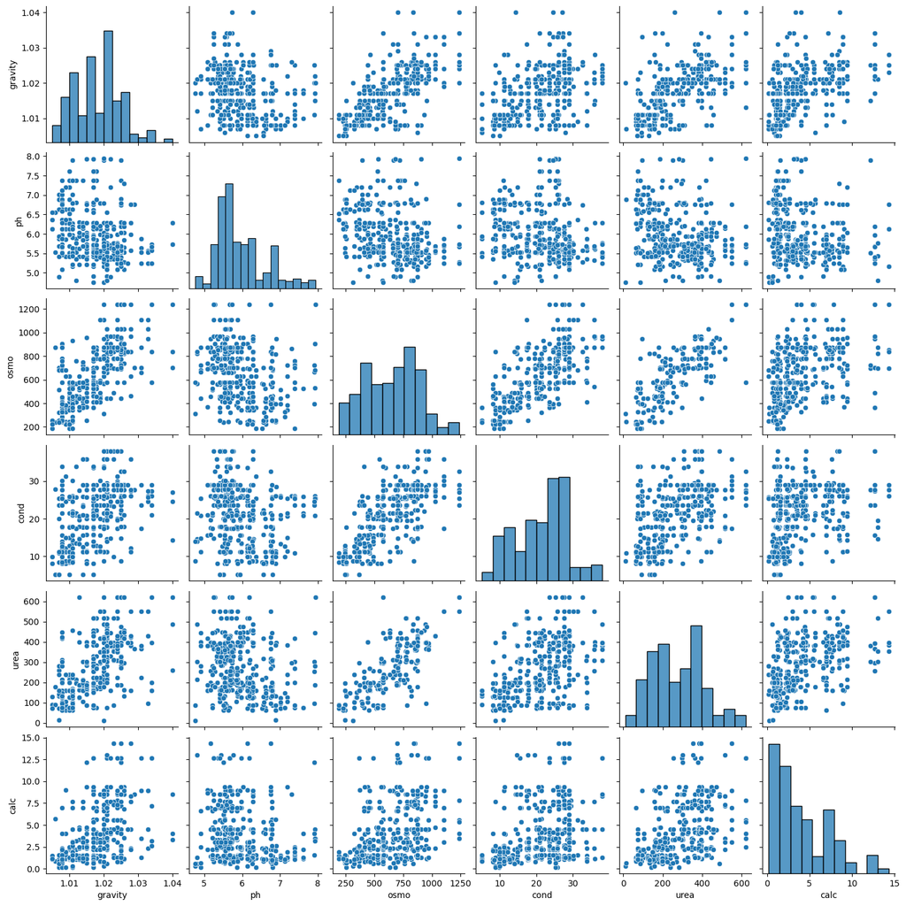

```python
sns.pairplot(train)
plt.show()
```

## 3.2 Correlation heatmap

There seems to be strong positive correlation between `urea` and `osmo`.

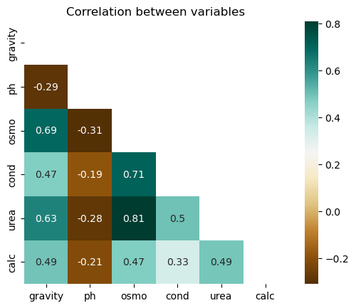

```python
corrs = train.corr()
mask = np.triu(np.ones_like(corrs, dtype = bool))
sns.heatmap(train.corr(), mask = mask, cmap = 'BrBG', annot = True, square = True)
plt.title('Correlation between variables')
plt.show()
```

# 4. Preprocessing

## 4.1 Missing values

The datasets have no missing values

```python
train.isna().sum()
```

```
gravity    0
ph         0
osmo       0
cond       0
urea       0
calc       0
dtype: int64
```

```python
test.isna().sum()
```

```
gravity    0
ph         0
osmo       0
cond       0
urea       0
calc       0
dtype: int64
```

## 4.2 Checking for variance

```python
train.var()
```

```
gravity        0.000045
ph             0.412498
osmo       55073.091109
cond          56.471464
urea       18616.487396
calc          10.353210
dtype: float64
```

## 4.3 Standardization

```python
scaler = StandardScaler()
# Fit transform the train set
train[train.columns] = scaler.fit_transform(train[train.columns])
X_train = train
# Transform the test set
test[train.columns] = scaler.fit_transform(test[train.columns])
X_test = test
```

# 5. Feature Selection

We will evaluate the contribution of each variable, and how important each variable is towards predicting the target variable

```python
roc_score = make_scorer(roc_auc_score)
kf = KFold(n_splits = 6, shuffle = True, random_state = 987)
```

## 5.1 Feature selection with Random Forests

Using random forests, all variables have a significant contribution towards explaining the variance. However, calc explains the highest variance of 32% with the rest of the variables having a contribution of between 12% and 15%. Using this model, no further feature selection will be done since the all variables have a significant contribution to the model.

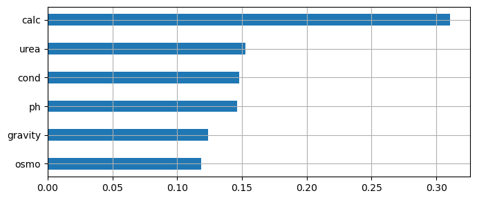

```python
rf = RandomForestClassifier()

# Fit the classifier
rf.fit(X_train, y_train)

# Retrieve the feature importances
rf_importance = pd.Series(rf.feature_importances_, index = rf.feature_names_in_)
rf_importance = rf_importance.sort_values(ascending = True)

# Visualizing the feature importances
fig = plt.figure(figsize = (7,3))
rf_importance.plot(kind = 'barh', width =0.4)
plt.grid(True)
plt.tight_layout()
plt.show()
```

```python
rf = RandomForestClassifier()

for features in list(range(6,0,-1)):
    rfe = RFE(estimator = rf, n_features_to_select = features, step = 1)
    results = cross_val_score(rfe, X_train,y_train, cv = kf, scoring = roc_score)
    print(f'Average roc_score is {np.mean(results)} with {features} features')
```

```
Average roc_score is 0.7117322164302565 with 6 features
Average roc_score is 0.7052303849284249 with 5 features
Average roc_score is 0.7221464539386376 with 4 features
Average roc_score is 0.7191599708581641 with 3 features
Average roc_score is 0.657651071398477 with 2 features
Average roc_score is 0.6899774225072589 with 1 features
```

## 5.2 Feature selection with xgboost

Using xgboost, all features have a significant contribution to explaining the variance in the target variable. Calc and pH however have the highest variance with the other variables variance being significant to the model.

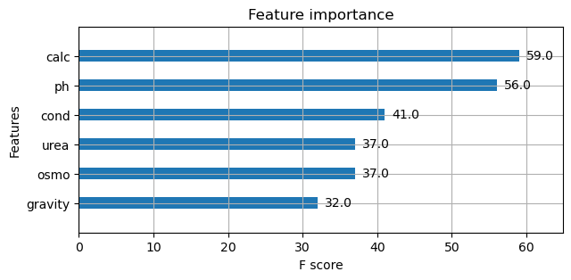

```python
# Convert the data to dmatrix
kidney_matrix = xgb.DMatrix(data = X_train, label = y_train)
params = {'objective':'binary:logistic'}

# Train data using dmatrix format
xgb_clf = xgb.train(dtrain = kidney_matrix, params = params, num_boost_round = 10)

# Plot the feature importances
fig, ax  = plt.subplots(figsize = (7,3))
xgb.plot_importance(xgb_clf, ax = ax, height = 0.4)
plt.show()
```

```python
xgb_cl = xgb.XGBClassifier(objective = 'binary:logistic')

for features in list(range(6,0,-1)):
    rfe = RFE(estimator = xgb_cl, n_features_to_select = features, step = 1)
    results = cross_val_score(rfe, X_train,y_train, cv = kf, scoring = roc_score)
    print(f'Average roc_score is {np.mean(results)} with {features} features')
```

```
Average roc_score is 0.6836649904754531 with 6 features
Average roc_score is 0.6690869675960366 with 5 features
Average roc_score is 0.675693935069967 with 4 features
Average roc_score is 0.6842346590518674 with 3 features
Average roc_score is 0.6703690984341014 with 2 features
Average roc_score is 0.7038162227858674 with 1 features
```

## 5.3 Feature selection with Logistic Regression

In logistic regression, the size of the coefficients determine their magnitude of contribution. Those close to zero have little contribution while large coefficients are an indicator that the variable has a high effect on the target variable. In our problem, the `calc` variable has the biggest coefficient.

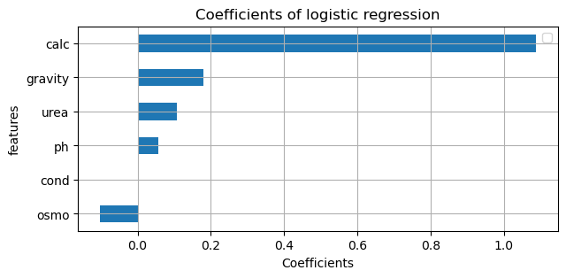

```python
logreg = LogisticRegression()

logreg.fit(X_train, y_train)
logreg_coeffs = pd.DataFrame({'coeffs':logreg.coef_[0], 'features':logreg.feature_names_in_}).set_index('features').sort_values(by='coeffs')
fig, ax  = plt.subplots(figsize = (7,3))
logreg_coeffs.plot(kind = 'barh',ax = ax)
plt.grid(True)
plt.xlabel('Coefficients')
plt.title('Coefficients of logistic regression')
plt.legend("")
plt.show()
```

```python
logreg = LogisticRegression()

for features in list(range(6,0,-1)):
    rfe = RFE(estimator = logreg, n_features_to_select = features, step = 1)
    results = cross_val_score(rfe, X_train,y_train, cv = kf, scoring = roc_score)
    print(f'Average roc_score is {np.mean(results)} with {features} features')
```

```
Average roc_score is 0.7062864438539588 with 6 features
Average roc_score is 0.7073548199223348 with 5 features
Average roc_score is 0.7099511491517011 with 4 features
Average roc_score is 0.6987394849988604 with 3 features
Average roc_score is 0.6998665726854556 with 2 features
Average roc_score is 0.7108680001723305 with 1 features
```

# 6. Model Prediction

```python
classifiers = [
    ('logistic regression',LogisticRegression()),
    ('random forest', RandomForestClassifier()),
    ('xgboost',xgb.XGBClassifier(objective='binary:logistic')),
    ('gradient boosting',GradientBoostingClassifier(loss='log_loss')),
    ('svc',SVC(probability = True)),
    ('ada',AdaBoostClassifier())
]
```

```python
vc = VotingClassifier(estimators = classifiers, voting = 'soft', n_jobs =-1)

classifiers = [
    ('logistic regression',LogisticRegression()),
    ('random forest', RandomForestClassifier()),
    ('xgboost',xgb.XGBClassifier(objective='binary:logistic')),
    ('gradient boosting',GradientBoostingClassifier(loss='log_loss')),
    ('svc',SVC(probability = True)),
    ('ada',AdaBoostClassifier(estimator = RandomForestClassifier())),
    ('voting classifier',vc)
]
for name, clf in classifiers:
    results = cross_val_score(clf, X_train,y_train, cv = kf, scoring = roc_score)
    print(f'Average roc_score is {np.mean(results)} for {name} classifier')
```

```
Average roc_score is 0.7062864438539588 for logistic regression classifier
Average roc_score is 0.7139473553593914 for random forest classifier
Average roc_score is 0.6836649904754531 for xgboost classifier
Average roc_score is 0.7010886862507221 for gradient boosting classifier
Average roc_score is 0.7183340138432359 for svc classifier
Average roc_score is 0.7146129764080493 for ada classifier
Average roc_score is 0.7226152112912692 for voting classifier classifier
```

# 7. Hyperparameter Tuning

## 7.1 Logistic Regression

```python
logreg = LogisticRegression(n_jobs = -1)
param_grid = {
    'C':[0.1]
}

logreg_cv = GridSearchCV(logreg, param_grid = param_grid, cv=kf, scoring = roc_score)
logreg_cv.fit(X_train, y_train)
print('Average score',logreg_cv.cv_results_['mean_test_score'][0])
print(logreg_cv.best_params_)

logreg_tuned = logreg_cv.best_estimator_
```

```
Average score 0.7115880936916127
{'C': 0.1}
```

## 7.2 Random forest

```python
rf = RandomForestClassifier(n_jobs = -1, random_state = 987)
param_grid = {
    'n_estimators':[200], 'max_depth':[2], 'max_samples':[0.4]
}

rf_cv = GridSearchCV(rf, param_grid = param_grid, cv = kf, scoring = roc_score)
rf_cv.fit(X_train, y_train)
print('Average score',rf_cv.cv_results_['mean_test_score'][0])
print(rf_cv.best_params_)

rf_tuned = rf_cv.best_estimator_
```

```
Average score 0.7335363624404381
{'max_depth': 2, 'max_samples': 0.4, 'n_estimators': 200}
```

## 7.3 Xgboost

```python
xgb_cl = xgb.XGBClassifier(random_state = 987, n_jobs = -1)
param_grid = {
    'objective':['binary:logistic'], 'n_estimators':[10], 'reg_alpha':[0.001]
}

xgb_cl_cv = GridSearchCV(xgb_cl, param_grid = param_grid, cv = kf, scoring = roc_score)
xgb_cl_cv.fit(X_train, y_train)
print('Average score',xgb_cl_cv.cv_results_['mean_test_score'][0])
print(xgb_cl_cv.best_params_)

xgb_tuned = xgb_cl_cv.best_estimator_
```

```
Average score 0.7428868798871511
{'n_estimators': 10, 'objective': 'binary:logistic', 'reg_alpha': 0.001}
```

## 7.4 Gradient boosting

```python
gradient = GradientBoostingClassifier(random_state = 987)

param_grid = {
    'loss':['log_loss'],'n_estimators':[40], 'subsample':[0.4], 'ccp_alpha':[0.001]
}

gradient_cv = GridSearchCV(gradient, param_grid = param_grid, cv = kf, scoring = roc_score)
gradient_cv.fit(X_train, y_train)

print('Average score',gradient_cv.cv_results_['mean_test_score'][0])
print(gradient_cv.best_params_)

gradient_tuned = gradient_cv.best_estimator_
```

```
Average score 0.7315892153234126
{'ccp_alpha': 0.001, 'loss': 'log_loss', 'n_estimators': 40, 'subsample': 0.4}
```

## 7.5 SVC

```python
svc = SVC(probability = True, random_state = 987)

param_grid = {
    'C':[1]
}

svc_cv = GridSearchCV(svc, param_grid = param_grid, cv = kf, scoring = roc_score)
svc_cv.fit(X_train, y_train)

print('Average score',svc_cv.cv_results_['mean_test_score'][0])
print(svc_cv.best_params_)

svc_tuned = svc_cv.best_estimator_
```

```
Average score 0.7183340138432359
{'C': 1}
```

## 7.6 AdaBoost

```python
ada = AdaBoostClassifier(random_state = 987)

param_grid = {
    'estimator':[rf_tuned], 'learning_rate':[0.2], 'n_estimators':[40]
}

ada_cv = GridSearchCV(ada, param_grid = param_grid, cv = kf, scoring = roc_score,verbose=1)
ada_cv.fit(X_train, y_train)

print('Average score',ada_cv.cv_results_['mean_test_score'][0])
print(ada_cv.best_params_)

ada_tuned = ada_cv.best_estimator_
```

[output not shown]

# 8. Predictions

```python
classifiers = [
    ('xgboost',xgb_tuned),
    ('ada',ada_tuned),
    ('random forest', rf_tuned)
    #('gradient boosting',gradient_tuned)
    #('svc',svc_tuned)
    #('logistic regression',logreg_tuned)
]

vc_tuned = VotingClassifier(estimators = classifiers, voting = 'soft', n_jobs =-1)
```

```python
classifiers = [
    ('xgboost',xgb_tuned),
    ('ada',ada_tuned),
    ('random forest', rf_tuned),
    ('gradient boosting',gradient_tuned),
    ('svc',svc_tuned),
    ('logistic regression',logreg_tuned),
    ('voting classifier',vc_tuned)
]
df_list = []
for name, clf in classifiers:
    results = cross_val_score(clf, X_train,y_train, cv = kf, scoring = roc_score)
    #print(f'Average roc_score is {np.mean(results)} for {name} classifier')
    df_list.append({'classifier':name, 'roc_score':np.mean(results)})

df = pd.DataFrame(df_list).sort_values(by = 'roc_score', ascending = False)
df
```

|  | classifier | roc_score |
| --- | --- | --- |
| 6 | voting classifier | 0.745122 |
| 0 | xgboost | 0.742887 |
| 1 | ada | 0.736721 |
| 2 | random forest | 0.733536 |
| 3 | gradient boosting | 0.731589 |
| 4 | svc | 0.718334 |
| 5 | logistic regression | 0.711588 |

```python
vc_tuned.fit(X_train, y_train)
y_preds = vc_tuned.predict_proba(X_test)[:,1]
y_preds = np.round(y_preds,2)
submission_df = pd.DataFrame({'id':X_test.index,'target':y_preds})
submission_df.head()
```

|  | id | target |
| --- | --- | --- |
| 0 | 414 | 0.40 |
| 1 | 415 | 0.55 |
| 2 | 416 | 0.71 |
| 3 | 417 | 0.52 |
| 4 | 418 | 0.31 |

```python
submission_df.to_csv('submission.csv', index = False)
```